# Airbnb Analysis

## Chart 1:

```
## $`Airbnb Houses that User left reviews such as COVID, Remote Work, Workation and so on`
```

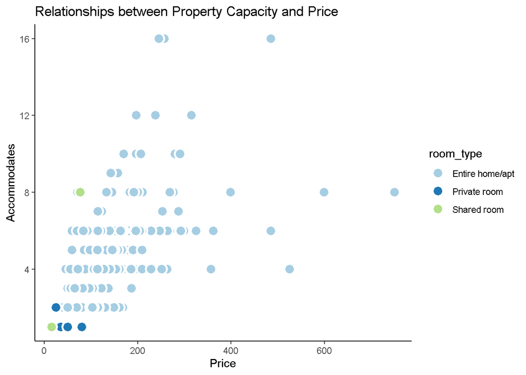

```
##
## $`Airbnb Houses that User left simple reviews (no word filter)`
```

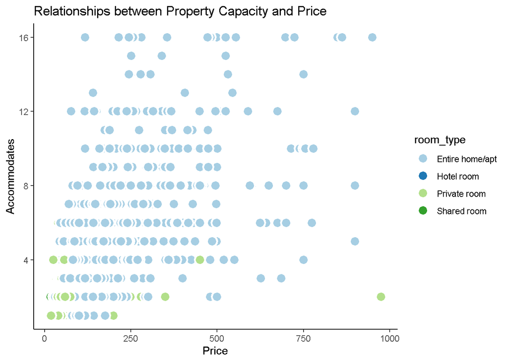

## Chart 2:

```
## $`Airbnb Houses that User left reviews such as COVID, Remote Work, Workation and so on`
```

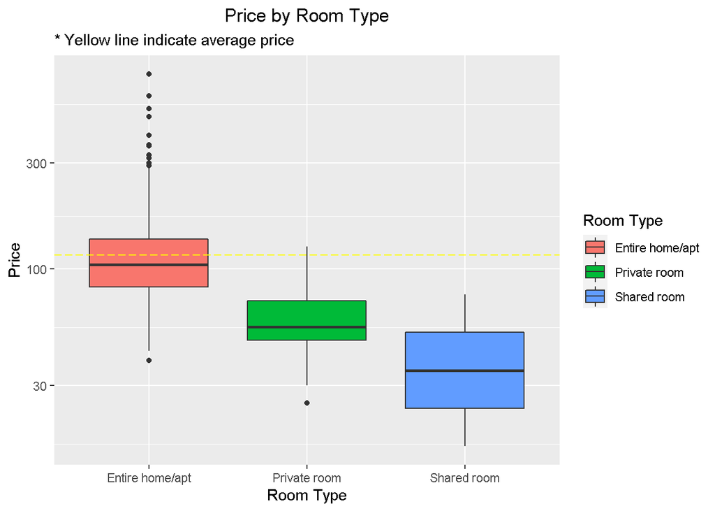

```
##
## $`Airbnb Houses that User left simple reviews (no word filter)`
```

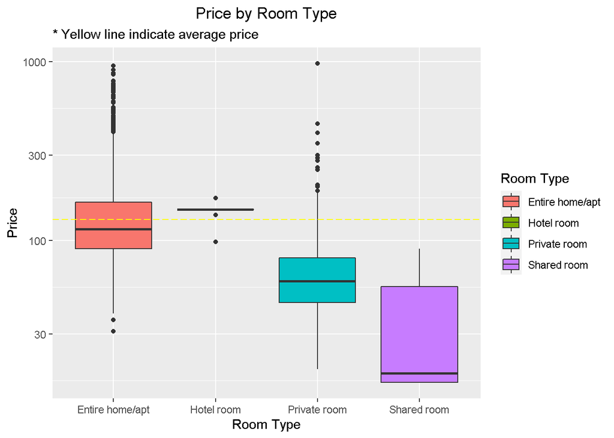

## Chart 3:

[interactive chart not shown]

This figure is a geographic representation of Airbnb’s location in Seattle. The property dataset was filtered, and the filter conditions used the following words in the review comments left by users after January 1, 2020.

- “COVID|COVID-19|coronavirus|covid|virus|pandemic|remote|remote work|workation|staycation”

This filtering allows us to hypothesize that the facilities were used to refresh the pandemic, remote work, etc. The colors of the graphs are color-coded by the minimum number of nights set for each facility. As can be seen, most of the accommodations have a minimum stay requirement of between 20 and 30 days, i.e., it is offered in the form of monthly stays.

Plus, if ｗe look closely at the marked locations, it is telling that most are located on land with good views, such as Lake Washington and Elliott Bay. Of course, there are still some users around downtown, as there were several facilities in the first place. Still, most of them are not for business use, so it seems that people prefer the pretty scenery and the less hustle and bustle, rather than being particularly aware of the accessibility. It’s hard to say for sure if this trend is happening all over the world in Seattle alone. Still, I think the graphing took into account the Airbnb demographic’s demand in this situation right now and the desire of owners to improve their cash flow as much as possible.

In the final version, I’ll use the Tokyo dataset to compare trends between the U.S. and Japan and then analyze further user demographic demand at this Airbnb stage.